# NYC Motor and Vehicle Car Collisions

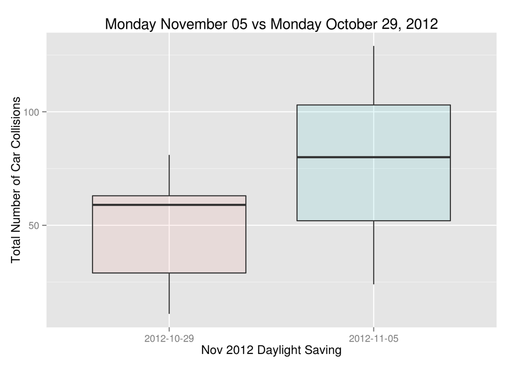

```r
      # -> Comparing the two dates in average
ggplot(na.omit(nov_12), aes(x = date, y = dls)) +
  geom_boxplot(aes(fill = date), alpha = 0.1) +
   guides(fill=FALSE) +
  labs(x = "Nov 2012 Daylight Saving",
       y = "Total Number of Car Collisions",
       title = "Monday November 05 vs Monday October 29, 2012")
```

```r
      # Since we wanted to be precise on how much the Daylight Savings affected the number of car collision, we decided to subtract the number of car collisions after the Daylight Saving on Monday, Nov 5 2012 from the previous Monday, Oct 29 2015
bk_n12 = filter(nov_12, borough=="BROOKLYN")
bk_n12_diff <- bk_n12[2,4] - bk_n12[1,4]
bk_n12_diff
```

```
##   dls
## 1  48
```

```r
bx_n12 = filter(nov_12, borough=="BRONX")
bx_n12_diff <- bx_n12[2,4] - bx_n12[1,4]
bx_n12_diff
```

```
##   dls
## 1  23
```

```r
qn_n12 = filter(nov_12, borough=="QUEENS")
qn_n12_diff <- qn_n12[2,4] - qn_n12[1,4]
qn_n12_diff
```

```
##   dls
## 1  40
```

```r
mn_n12 = filter(nov_12, borough=="MANHATTAN")
mn_n12_diff <- mn_n12[2,4] - mn_n12[1,4]
mn_n12_diff
```

```
##   dls
## 1  21
```

```r
st_n12= filter(nov_12, borough == "STATEN ISLAND")
st_n12_diff <- st_n12[2,4] - st_n12[1,4]
st_n12_diff
```

```
##   dls
## 1  13
```

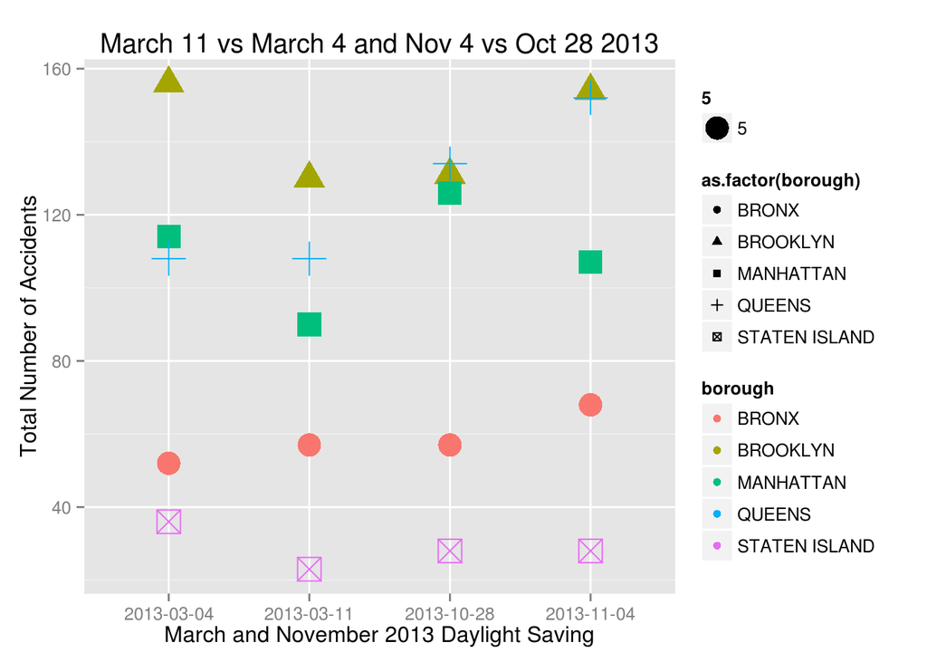

```r
    # b) The Daylight Saving occured on Sunday, March 10, 2:00 AM   Sunday, November 3, 2:00 AM 2013. Therefore, we analyzed March 11 vs March 4 and Nov 4 vs Oct 28 2013 to see if the number of car collisions were augmented when the clock was moved clockwise and counterclockwise. On March 2013, our results showed that the Daylight Saving time increased the number of car collisons in the Bronx only. On the other hand, on November 2013 the data showed that  the DLS tremendously increase the number of car collisions in the Bronx, Brooklyn, and Queens.

mar_and_nov_13 <- daylight_saving[daylight_saving$date == "2013-03-11" |
                            daylight_saving$date == "2013-03-04" |
                            daylight_saving$date == "2013-11-04" |
                            daylight_saving$date == "2013-10-28", ]
      # -> Comparing each individualy borough for the two Mondays
ggplot(mar_and_nov_13, aes(x = date, y = dls, colour = borough)) +
  geom_point(aes(shape = as.factor(borough), size = 5))+
  scale_size_area() +
  ggtitle("March 11 vs March 4 and Nov 4 vs Oct 28 2013")+
  xlab("March and November 2013 Daylight Saving")+
  ylab("Total Number of Accidents")
```

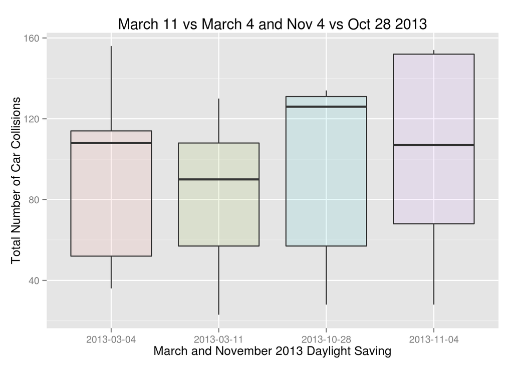

```r
      # -> Comparing the two dates in average
ggplot(na.omit(mar_and_nov_13), aes(x = date, y = dls)) +
  geom_boxplot(aes(fill = date), alpha = 0.1) +
   guides(fill=FALSE) +
  labs(x = "March and November 2013 Daylight Saving",
       y = "Total Number of Car Collisions",
       title = "March 11 vs March 4 and Nov 4 vs Oct 28 2013")
```

```r
      # Since we wanted to be precise on how much the Daylight Savings affected the number of car collision, we decided to subtract the number of car collisions after the Daylight Saving on Monday, March 11 from the previous Monday, March 4 2013
bk_m13 = filter(mar_and_nov_13, borough=="BROOKLYN")
bk_m13_diff <- bk_m13[2,4] - bk_m13[1,4]
bk_m13_diff
```

```
##   dls
## 1 -26
```

```r
bx_m13 = filter(mar_and_nov_13, borough=="BRONX")
bx_m13_diff <- bx_m13[2,4] - bx_m13[1,4]
bx_m13_diff
```

```
##   dls
## 1   5
```

```r
qn_m13 = filter(mar_and_nov_13, borough=="QUEENS")
qn_m13_diff <- qn_m13[2,4] - qn_m13[1,4]
qn_m13_diff
```

```
##   dls
## 1   0
```

```r
mn_m13 = filter(mar_and_nov_13, borough=="MANHATTAN")
mn_m13_diff <- mn_m13[2,4] - mn_m13[1,4]
mn_m13_diff
```

```
##   dls
## 1 -24
```

```r
st_m13= filter(mar_and_nov_13, borough == "STATEN ISLAND")
st_m13_diff <- st_m13[2,4] - st_m13[1,4]
st_m13_diff
```

```
##   dls
## 1 -13
```

```r
      # Since we wanted to be precise on how much the Daylight Savings affected the number of car collision, we decided to subtract the number of car collisions after the Daylight Saving on Monday, Nov 4 from the previous Monday, Oct 28 2013
bk_n13 = filter(mar_and_nov_13, borough=="BROOKLYN")
bk_n13_diff <- bk_n13[4,4] - bk_n13[3,4]
bk_n13_diff
```

```
##   dls
## 1  23
```

```r
bx_n13 = filter(mar_and_nov_13, borough=="BRONX")
bx_n13_diff <- bx_n13[4,4] - bx_n13[3,4]
bx_n13_diff
```

```
##   dls
## 1  11
```

```r
qn_n13 = filter(mar_and_nov_13, borough=="QUEENS")
qn_n13_diff <- qn_n13[4,4] - qn_n13[3,4]
qn_n13_diff
```

```
##   dls
## 1  18
```

```r
mn_n13 = filter(mar_and_nov_13, borough=="MANHATTAN")
mn_n13_diff <- mn_n13[4,4] - mn_n13[3,4]
mn_n13_diff
```

```
##   dls
## 1 -19
```

```r
st_n13= filter(mar_and_nov_13, borough == "STATEN ISLAND")
st_n13_diff <- st_n13[4,4] - st_n13[3,4]
st_n13_diff
```

```
##   dls
## 1   0
```

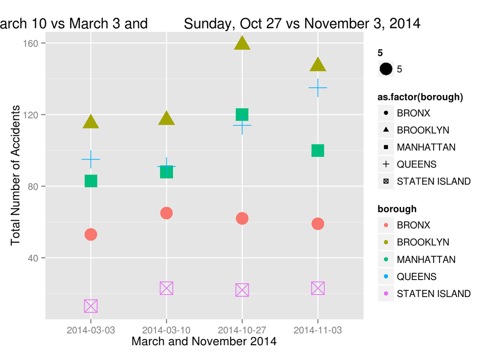

```r
  # c) The Daylight Saving occured on Sunday, March 9, 2:00 AM  Sunday, November 2, 2:00 AM 2014. Therefore, we analyzed March 10 vs March 3 and Nov 3 vs Oct 27 2014 to see if the number of car collisions were augmented when the clock was moved clockwise and counterclockwise. On March 2014, our results showed that the DLS tremendously increased the number of car collisions on Brooklyn, Bronx, Staten Island and Manhattan only. Similarly, on November 2014, Staten Island and Queens were the only affected boroughs were the Daylight Saving Time augmented the number of car collisions.

mar_and_nov_14 <- daylight_saving[daylight_saving$date == "2014-03-10" |
                                    daylight_saving$date == "2014-03-03" |
                                    daylight_saving$date == "2014-11-03" |
                                    daylight_saving$date == "2014-10-27", ]

        # -> Comparing each individualy borough for the two Mondays
ggplot(mar_and_nov_14, aes(x = date, y = dls, colour = borough)) +
  geom_point(aes(shape = as.factor(borough), size = 5))+
  scale_size_area()+
  ggtitle("March 10 vs March 3 and  Sunday, Oct 27 vs November 3, 2014")+
  xlab("March and November 2014")+
  ylab("Total Number of Accidents")
```

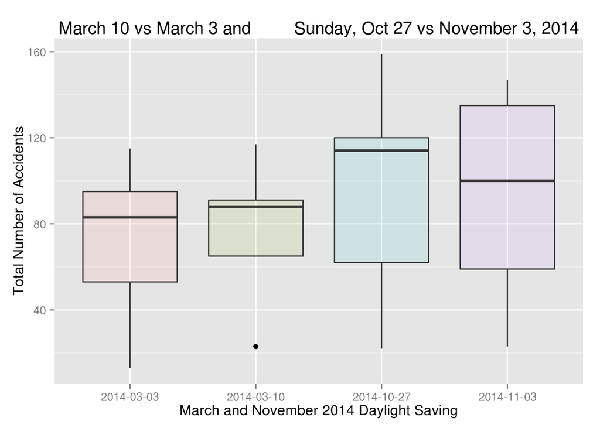

```r
        # -> Comparing the two dates in average
ggplot(na.omit(mar_and_nov_14), aes(x = date, y = dls)) +
  geom_boxplot(aes(fill = date), alpha = 0.1) +
   guides(fill=FALSE) +
  labs(x = "March and November 2014 Daylight Saving",
       y = "Total Number of Accidents",
       title = "March 10 vs March 3 and Sunday, Oct 27 vs November 3, 2014")
```

```r
        # Since we wanted to be precise on how much the Daylight Savings affected the number of car collision, we decided to subtract the number of car collisions after the Daylight Saving on Monday, March 10 from the previous Monday, March 3 2013
bk_m14 = filter(mar_and_nov_14, borough=="BROOKLYN")
bk_m14_diff <- bk_m14[2,4] - bk_m14[1,4]
bk_m14_diff
```

```
##   dls
## 1   2
```

```r
bx_m14 = filter(mar_and_nov_14, borough=="BRONX")
bx_m14_diff <- bx_m14[2,4] - bx_m14[1,4]
bx_m14_diff
```

```
##   dls
## 1  12
```

```r
qn_m14 = filter(mar_and_nov_14, borough=="QUEENS")
qn_m14_diff <- qn_m14[2,4] - qn_m14[1,4]
qn_m14_diff
```

```
##   dls
## 1  -4
```

```r
mn_m14 = filter(mar_and_nov_14, borough=="MANHATTAN")
mn_m14_diff <- mn_m14[2,4] - mn_m14[1,4]
mn_m14_diff
```

```
##   dls
## 1   5
```

```r
st_m14= filter(mar_and_nov_14, borough == "STATEN ISLAND")
st_m14_diff <- st_m14[2,4] - st_m14[1,4]
st_m14_diff
```

```
##   dls
## 1  10
```

```r
      # Since we wanted to be precise on how much the Daylight Savings affected the number of car collision, we decided to subtract the total number of car collisions after the Daylight Saving on Monday, Nov 3 from the previous Monday, Oct 27 2014

bk_n14 = filter(mar_and_nov_14, borough=="BROOKLYN")
bk_n14_diff <- bk_n14[4,4] - bk_n14[3,4]
bk_n14_diff
```

```
##   dls
## 1 -12
```

```r
bx_n14 = filter(mar_and_nov_14, borough=="BRONX")
bx_n14_diff <- bx_n14[4,4] - bx_n14[3,4]
bx_n14_diff
```

```
##   dls
## 1  -3
```

```r
qn_n14 = filter(mar_and_nov_14, borough=="QUEENS")
qn_n14_diff <- qn_n14[4,4] - qn_n14[3,4]
qn_n14_diff
```

```
##   dls
## 1  21
```

```r
mn_n14 = filter(mar_and_nov_14, borough=="MANHATTAN")
mn_n14_diff <- mn_n14[4,4] - mn_n14[3,4]
mn_n14_diff
```

```
##   dls
## 1 -20
```

```r
st_n14= filter(mar_and_nov_14, borough == "STATEN ISLAND")
st_n14_diff <- st_n14[4,4] - st_n14[3,4]
st_n14_diff
```

```
##   dls
## 1   1
```

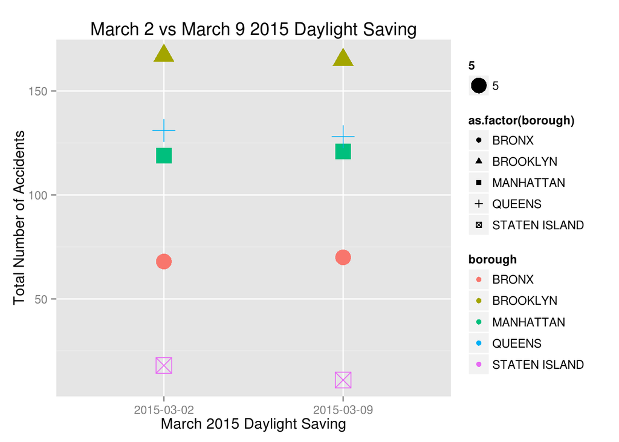

```r
  # d) The Daylight Saving Time in NYC was on Sunday, March 8, 2:00 AM  Sunday, November 1, 2:00 AM 2015. Since we are currently in November 2015 the NYC Open Data haven't displayed the dataset online. Therefore, we just focused on analyzing March 9 and March 2, 2015.

mar_15 <- daylight_saving[daylight_saving$date == "2015-03-09" |
                            daylight_saving$date == "2015-03-02", ]

      # -> Comparing each individualy borough for the two Mondays
ggplot(mar_15, aes(x = date, y = dls, colour = borough)) +
  geom_point(aes(shape = as.factor(borough), size = 5))+
  scale_size_area()+
  ggtitle("March 2 vs March 9 2015 Daylight Saving")+
  xlab("March 2015 Daylight Saving")+
  ylab("Total Number of Accidents")
```

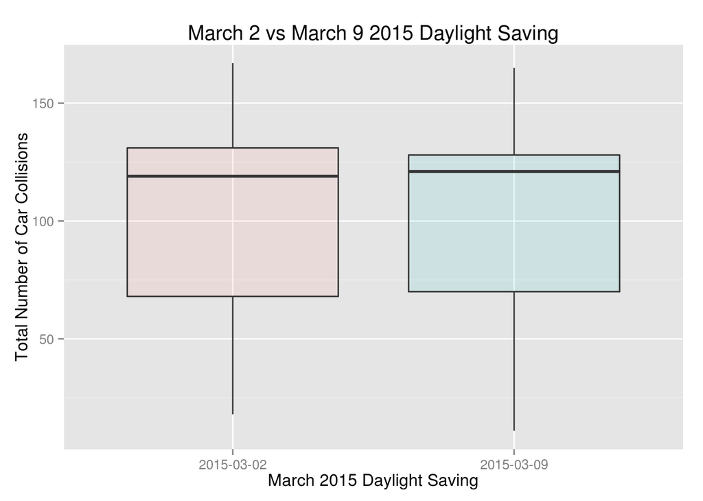

```r
      # -> Comparing the two dates in average
ggplot(na.omit(mar_15), aes(x = date, y = dls)) +
  geom_boxplot(aes(fill = date), alpha = 0.1) +
   guides(fill=FALSE) +
  labs(x = "March 2015 Daylight Saving",
       y = "Total Number of Car Collisions",
       title = "March 2 vs March 9 2015 Daylight Saving")
```

```r
        # Since we wanted to be precise on how much the Daylight Savings affected the number of car collision, we decided to subtractthe day after the Daylight Saving on Monday, March 9 from the previous Monday, March 2 2015
bk_m15 = filter(mar_15, borough=="BROOKLYN")
bk_m15_diff <- bk_m15[2,4] - bk_m15[1,4]
bk_m15_diff
```

```
##   dls
## 1  -2
```

```r
bx_m15 = filter(mar_15, borough=="BRONX")
bx_m15_diff <- bx_m15[2,4] - bx_m15[1,4]
bx_m15_diff
```

```
##   dls
## 1   2
```

```r
qn_m15 = filter(mar_15, borough=="QUEENS")
qn_m15_diff <- qn_m15[2,4] - qn_m15[1,4]
qn_m15_diff
```

```
##   dls
## 1  -3
```

```r
mn_m15 = filter(mar_15, borough=="MANHATTAN")
mn_m15_diff <- mn_m15[2,4] - mn_m15[1,4]
mn_m15_diff
```

```
##   dls
## 1   2
```

```r
st_m15= filter(mar_15, borough == "STATEN ISLAND")
st_m15_diff <- st_m15[2,4] - st_m15[1,4]
st_m15_diff
```

```
##   dls
## 1  -7
```

3. Most of the time, the Daylight Saving Time on November increased the number of car collisions. Therefore, we decided to further investigate the reasons why most of the car accidents occured in NYC. Our results demonstrated that on Manhattan, Brooklyn, Queens, and the Bronx we have the highest number of car collision due to driving inattention. According to the Advances in Research by professor Michael Regan he said that 71% of the crashes occured, 46% of the crashes-near, and 60% of the SCEs were caused in non-driving task just before the occurance of the kinematics trigger. 77% occured by texting where the driver’s eyes were off the forward roadway which caused cognitive distration. My results proves his point by showing all higher causes of car collisions.

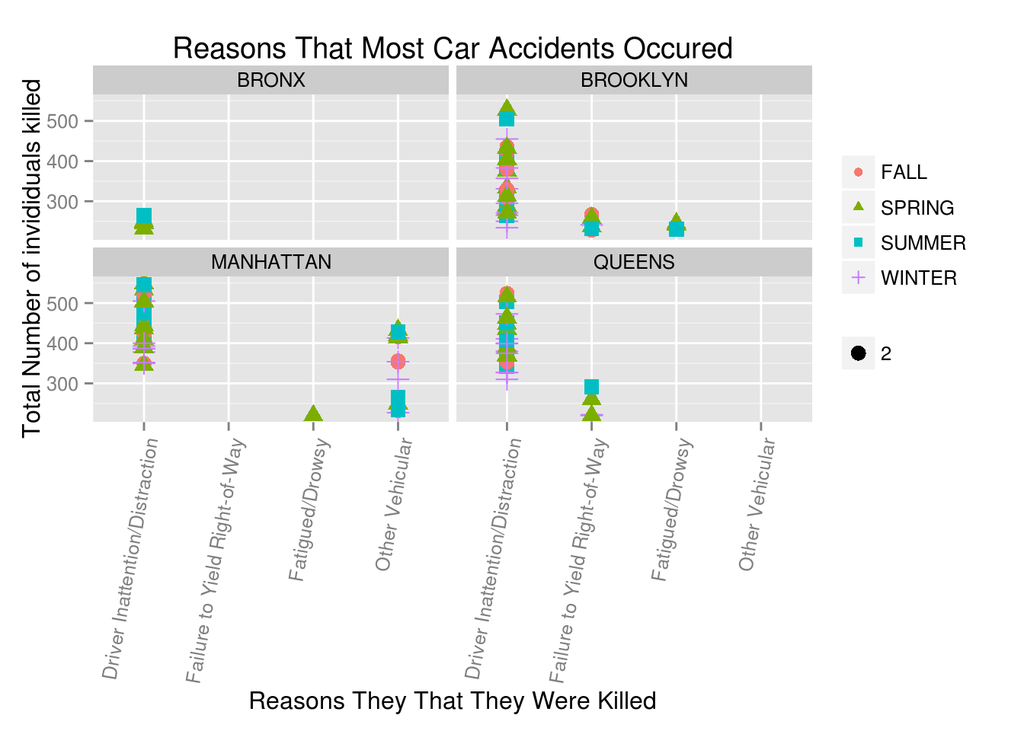

```r
  # a) Calculations
reasons_type <- car_collision %>%
  group_by(borough, year_month, season, reason_vehicle1_crashed) %>%
  summarize(reasons = n())

  # b) Arranging the data so I can obtain the high reasons that caused car collisions. We know that for each reason 631 is the max number of car collisions. Therefore, in order to find the top 5 reasons I will filter the data
reasons_type <- filter(reasons_type, reason_vehicle1_crashed != "Unspecified")
reasons_type <- filter(reasons_type, reasons >= 220)

  # c) Plot the highest causes of car collisions for each borough
ggplot(reasons_type, aes(x = reason_vehicle1_crashed, y = reasons, color = as.factor(season)))+
  geom_point(aes(shape = as.factor(season), size = 2))+
  ggtitle("Reasons That Most Car Accidents Occured")+
  xlab("Reasons They That They Were Killed")+
  ylab("Total Number of invididuals killed")+
  facet_wrap(~ borough)+
  scale_y_continuous(limits=c(220, 550))+
  theme(legend.title=element_blank(),
        axis.text.x=element_text(angle=80, hjust=1),
        legend.background = element_rect(fill = "transparent"))
```